# Random Variables

b06208001 龔泓愷

2018年10月5日

#### 8.18

1. RR(X=0)、RL(X=1)、LR(X=1)、LL(X=2)
2. P(RR) = 7/10 * 6/9 = 42/90  
   P(RL) = 7/10 * 3/9 = 21/90  
   P(LR) = 3/10 * 7/9 = 21/90  
   P(LL) = 3/10 * 2/9 = 6/90
3. P(X) = {X = 0 or 1 P(X) = 42/90, X = 2 P(X) = 6/90, X != 0, 1 or 2 P(X) = 0}

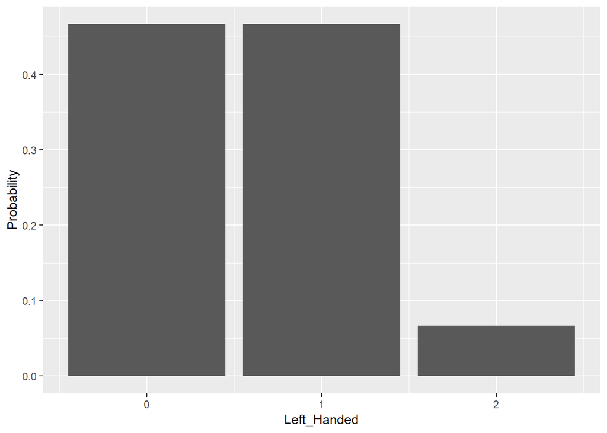

```r
Left_Handed <- c(0, 1, 2)
Probability <- c(42/90, 42/90, 6/90)
Q818 <- data.frame(Left_Handed, Probability)
library(ggplot2)
ggplot(Q818, aes(x = Left_Handed, y = Probability)) +
  geom_histogram(stat = 'identity')
```

#### 8.40

```r
0.2*20 + 0.8*15
```

```
## [1] 16
```

2. No, it’s not. It’s never equal to the actual commute time for the expected value refers to the **long run average**.

#### 8.50

```r
choose(10, 5)*(1/2)^5*(1/2)^5
```

```
## [1] 0.2460938
```

```r
dbinom(5, size = 10, prob = 0.5)
```

```
## [1] 0.2460938
```

```r
choose(10, 7)*(1/2)^7*(1/2)^3
```

```
## [1] 0.1171875
```

```r
dbinom(7, size = 10, prob = 0.5)
```

```
## [1] 0.1171875
```

```r
choose(10, 7)*(1/2)^7*(1/2)^3 + choose(10, 8)*(1/2)^8*(1/2)^2 + choose(10, 9)*(1/2)^9*(1/2)^1 + choose(10, 10)*(1/2)^10*(1/2)^0
```

```
## [1] 0.171875
```

```r
pbinom(6, size = 10, prob = 0.5, lower.tail = F)
```

```
## [1] 0.171875
```

#### 8.72

mean = 500, sd = 100  
a. P(X<=500)，half of the population which its probability equals 0.5

```r
a <- pnorm(500, mean = 500, sd = 100)
a
```

```
## [1] 0.5
```

2. P(X<=650)

```r
pnorm(650, mean = 500, sd = 100)
```

```
## [1] 0.9331928
```

c.P(X>=700)

```r
c <- pnorm(700, mean = 500, sd = 100, lower.tail = F)
c
```

```
## [1] 0.02275013
```

d.P(500<=X<=700)

```r
(1-c) - a
```

```
## [1] 0.4772499
```

#### 8.82

1. For a binomial distribution：  
   mean = `np`  
   sd = `sqrt(np(1-p))`

```r
mean = 100 * 0.5
mean
```

```
## [1] 50
```

```r
sd = sqrt(100 * 0.5 * 0.5)
sd
```

```
## [1] 5
```

2. P(>=60) by normal distribution approximation.

```r
pnorm(60, mean = 50, sd = 5, lower.tail =  F)
```

```
## [1] 0.02275013
```

3. P(>=59.5) by normal distribution approximation.

```r
pnorm(59.5, mean = 50, sd = 5, lower.tail =  F)
```

```
## [1] 0.02871656
```

4. P(>=60) by binomial function.

```r
pbinom(59, size = 100, prob = 0.5, lower.tail = F)
```

```
## [1] 0.02844397
```

5. For a binomial distribution, the most accurate value will be caculated by using `pbinom()`, which is (d.).  
   On the other hand, the least accurate value will be caculated by using `pnorm()` without correction, which is (b.).

#### 8.90

1. Linear combinations of two normal distributions will be normal distribution as well.
2. `mean(X-Y) = mean(X) - mean(Y) = 0`  
   The mean supposed to be `0` if we did enough sampling.
3. `variance(X-Y) = variance(X) + variance(Y)`  
   `sd(X-Y) = sqrt(variance(X-Y)) = sqrt(variance(X) + variance(Y))`  
   The sd should be`sqrt(2.8^2 + 2.8^2) = 3.96` if we did enough sampling.

```r
#Setting
event = c()

for (i in 1:100000){

  sample <- rnorm(2, mean = 70, sd = 2.8)
  X = sample[1]
  Y = sample[2]
  D = X - Y

  event[i] = D
}
mean(event)
```

```
## [1] -0.01870092
```

```r
sd(event)
```

```
## [1] 3.966187
```

4. P(D > 3)

```r
pnorm(3, mean = 0, sd = 3.96, lower.tail =  F)
```

```
## [1] 0.2243525
```

5. P(D > 3| D <- 3)

```r
2*pnorm(3, mean = 0, sd = 3.96, lower.tail =  F)
```

```
## [1] 0.448705
```

#### Function Practice

- 某都市有10萬人口，某疾病每人每年感染機率為p = 0.01，請繪製該市每年感染人數頻率分布圖。

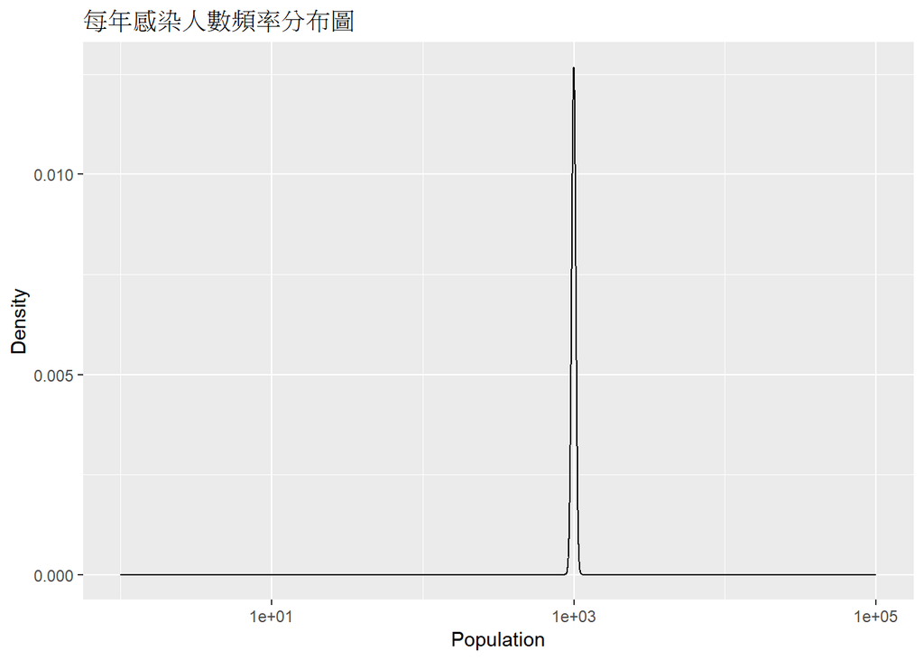

```r
Population = c(1:100000)
Density = dbinom(Population, size = 100000, prob = 0.01)
Data <- data.frame(Population, Density)
ggplot(Data, aes(x = Population, y = Density)) +
  geom_line() +
  scale_x_log10() +
  ggtitle('每年感染人數頻率分布圖')
```

- 市長承諾，該年感染超過1050就下台。請問4年內市長下台機率。

```r
d <- pbinom(1049, size = 100000, prob = 0.01, lower.tail = F) #P(>=1500) = 1- P(<=1049)每一年超過1050人得病的機率
pbinom(0, size = 4, prob = d, lower.tail = F)#P(>=1) = 1 - P(<=0) #至少一年有1050人以上
```

```
## [1] 0.2149261
```

- 電腦模擬針對100年發生最大疫情規模的年度，估計該年度感染人數。

```r
Disease <- function(n){
  #Setting
  disease.event = c()
  for(i in 1:n){ #模擬n年
    count = 0
    for (j in 1:100000){ #模擬10萬市民
      samp = sample(1:100, 1, replace = T)
      if (samp == 1){
        count = count + 1
      }
    }
    disease.event[i] = count
  }
  return(disease.event)
}
max(Disease(100))
```

```
## [1] 1076
```